# Activity: Popular Names

Suhail M.

June 2 2024

# Set Up

```r
# load necessary packages
library(tidyverse)
library(mosaic)
library(dcData)
```

```r
# Load the BabyNames data into RStudio environment (from dcData package)
data("BabyNames")
```

# Activity

**Goal**: By the end of the activity, each team will create a graph showing ups and downs in the popularity of four names according to the U.S. social security administration

### Step 1: use multiple summary functions to examine the data source

```r
summary(BabyNames)
```

```
     name               sex                count              year
 Length:1792091     Length:1792091     Min.   :    5.0   Min.   :1880
 Class :character   Class :character   1st Qu.:    7.0   1st Qu.:1948
 Mode  :character   Mode  :character   Median :   12.0   Median :1981
                                       Mean   :  186.1   Mean   :1972
                                       3rd Qu.:   32.0   3rd Qu.:2000
                                       Max.   :99674.0   Max.   :2013
```

```r
str(BabyNames)
```

```
'data.frame':   1792091 obs. of  4 variables:
 $ name : chr  "Mary" "Anna" "Emma" "Elizabeth" ...
 $ sex  : chr  "F" "F" "F" "F" ...
 $ count: int  7065 2604 2003 1939 1746 1578 1472 1414 1320 1288 ...
 $ year : int  1880 1880 1880 1880 1880 1880 1880 1880 1880 1880 ...
```

```r
glimpse(BabyNames)
```

```
Rows: 1,792,091
Columns: 4
$ name  <chr> "Mary", "Anna", "Emma", "Elizabeth", "Minnie", "Margaret", "Ida", "Al…
$ sex   <chr> "F", "F", "F", "F", "F", "F", "F", "F", "F", "F", "F", "F", "F", "F",…
$ count <int> 7065, 2604, 2003, 1939, 1746, 1578, 1472, 1414, 1320, 1288, 1258, 122…
$ year  <int> 1880, 1880, 1880, 1880, 1880, 1880, 1880, 1880, 1880, 1880, 1880, 188…
```

### Step 2: sketch the plot you plan to create–this does not have to be submitted

```r
# the names of interest
names_of_interest <- c("Suhail", "Mary", "Emma", "Anna")

# groupby withh year, name
GlyphReadyForm <- BabyNames %>%
                    filter(name %in% names_of_interest) %>%
                    group_by(year, name) %>%
                    summarize(total = sum(count), .groups = 'drop')
glimpse(GlyphReadyForm)
```

```
Rows: 435
Columns: 3
$ year  <int> 1880, 1880, 1880, 1881, 1881, 1881, 1882, 1882, 1882, 1883, 1883, 188…
$ name  <chr> "Anna", "Emma", "Mary", "Anna", "Emma", "Mary", "Anna", "Emma", "Mary…
$ total <int> 2616, 2013, 7092, 2714, 2043, 6948, 3143, 2310, 8178, 3322, 2374, 804…
```

### Step 3: attempt to answer all questions about the data

- The glyph-ready data will have the columns year, name, and total.
- Q. What variable(s) from the raw data table do not appear at all in the graph?

Ans : sex, count

- Q. What variable(s) in the graph are similar to corresponding variables in the raw data table, but might have been transformed in some way?

Ans : count variable is transformed to total in graph data

### Step 4: attempt to answer all questions about the data

- Q. Have cases been filtered out?

Ans : Yes, Based on 4 names

- Q. Have cases been grouped and summarized within groups in any way?

Ans : Yes, filtered data is grouped by year and name (due to gender neutral names)

- Q.Have any new variables been introduced? If so, what’s the relationship between the new variables and existing variables?

Ans : total varibale indicates total count of baby name for that year, it is related to existing count varible, only difference that count considers gender and total don’t

### Step 5: explanation of data wrangling steps in English (not code)

1. Load the libraries & BabyNames data.
2. Filter the data to include only the names of interest.
3. Group the data by year and name.
4. Summarize the total count for each name per year.
5. Create the glyph-ready data frame.
6. Plot the data using ggplot2.

### Step 6: complete this in your notes–this does not have to be submitted

### Step 7:Data wrangling…( modify the starter code given in the book to produce your own R code..)

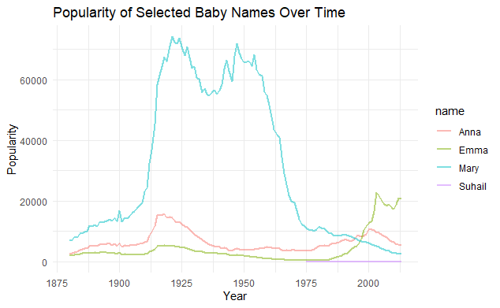

```r
 GlyphReadyForm%>%
  ggplot(aes(x = year, y = total, group = name, color = name)) +
  geom_line(linewidth = 1, alpha = 0.5) +
  ylab("Popularity") + xlab("Year") +
  theme_minimal() +
  ggtitle("Popularity of Selected Baby Names Over Time")
```